# Reproducible Research, project 2 : a study of storms impact in the US

Mathieu Besancon

Sunday, September 14, 2014

## Synopsis

The report was created for the Reproducible Research course on the Coursera plateform (see presentation [here](https://www.coursera.org/course/repdata). The analysis was performed using R and RStudio. More information [on the R project](http://www.R-project.org/).

The purpose of the analysis is to use the data available on storms in the USA to draw some conclusions on the storms having the biggest impacts on people’s health and on the economy.

The data were collected by the U.S. National Oceanic and Atmospheric Administration (NOAA).

## Data processing

The raw data are loaded into `storm_data`, we can take a look at the size and content of the dataset.

```r
storm_data<-read.csv("repdata-data-StormData.csv")
dim(storm_data)
```

```
## [1] 902297     37
```

```r
names(storm_data)
```

```
##  [1] "STATE__"    "BGN_DATE"   "BGN_TIME"   "TIME_ZONE"  "COUNTY"
##  [6] "COUNTYNAME" "STATE"      "EVTYPE"     "BGN_RANGE"  "BGN_AZI"
## [11] "BGN_LOCATI" "END_DATE"   "END_TIME"   "COUNTY_END" "COUNTYENDN"
## [16] "END_RANGE"  "END_AZI"    "END_LOCATI" "LENGTH"     "WIDTH"
## [21] "F"          "MAG"        "FATALITIES" "INJURIES"   "PROPDMG"
## [26] "PROPDMGEXP" "CROPDMG"    "CROPDMGEXP" "WFO"        "STATEOFFIC"
## [31] "ZONENAMES"  "LATITUDE"   "LONGITUDE"  "LATITUDE_E" "LONGITUDE_"
## [36] "REMARKS"    "REFNUM"
```

Since our dataset is huge, we will reduce it to some subsets for each specific need of the analysis. We create two subsets, `harm_data` for the consequences on human health and `eco_data` for the economic impact.

```r
use_att<-c("EVTYPE","FATALITIES","INJURIES")
harm_data<-storm_data[use_att]
eco_att<-c("EVTYPE","PROPDMG","PROPDMGEXP","CROPDMG","CROPDMGEXP")
eco_data<-storm_data[eco_att]
```

The multiplot function will also be used for plotting several graphs at a time. The code source is available on Cookbook for R.

### Studying the impact of storms on people’s health

For the impact on health, we consider two metrics as relevant, the amount of fatalities and the amount of fatalities and injuries per event (which we compute in a new attribute, `Harm`. We create two aggregations of the dataset,`agg_harm` for fatalities and `agg2` for the overall harms.

```r
harm_data$Harm<-harm_data$FATALITIES + harm_data$INJURIES
attach(harm_data)
agg_harm<-aggregate(FATALITIES~EVTYPE,FUN=sum)
agg2<-aggregate(Harm~EVTYPE,FUN=sum)
detach(harm_data)
```

We want to work only on events which affected fatalities and harms respectively, so we sort and clean the aggregated data, keeping only the interesting event types.

```r
# For fatalities
agg_harm<-agg_harm[order(-agg_harm$FATALITIES),]
agg_harm<-agg_harm[which(agg_harm$FATALITIES>0),]
total_fatal<-sum(agg_harm$FATALITIES)

# For all harms
agg2<-agg2[order(-agg2$Harm),]
agg2<-agg2[which(agg2$Harm>0),]
total_harm<-sum(agg2$Harm)
```

The cumulated percentage of the metric of interest can then be computed. We also find the observation index for which the cumulated effects reach 80%, `index_80` and `index_h` respectively.

```r
#For fatalities
agg_harm$Cumulated<-NA
agg_harm$Cumulated[1]<-agg_harm$FATALITIES[1]/total_fatal
agg_harm$Index<-1
index_80<-NULL
for (i in 2:(as.numeric((length(agg_harm$Cumulated))))){
        agg_harm[i,3]<-agg_harm[i-1,3]+(agg_harm[i,2]/total_fatal)
        agg_harm[i,4]<-i
}
for (i in 2:length(agg_harm$Cumulated)){
        if (agg_harm[i,3]>0.8){
                index_80<-(i)
                break
        }
}
#For all harms
agg2$Cumulated<-NA
agg2$Cumulated[1]<-agg2$Harm[1]/total_harm
agg2$Index<-1
index_h<-NULL
for (i in 2:(as.numeric((length(agg2$Cumulated))))){
        agg2[i,3]<-agg2[i-1,3]+(agg2[i,2]/total_harm)
        agg2[i,4]<-i
}
for (i in 2:length(agg2$Cumulated)){
        if (agg2[i,3]>0.8){
                index_h<-(i)
                break
        }
}
```

```r
par1<-ggplot(data=agg_harm,aes(Index,Cumulated))
par1<-par1+geom_line(ylab="Cumulated percentage of fatalities",col='red',size=1.1)
par1<-par1+labs(y="Cumulated fraction of fatalities",title="Pareto analysis for fatalities")
par1<-par1+xlim(c(0,NA))+ylim(c(0,1))
par1<-par1+geom_abline(intercept=0,slope=(1/length(agg_harm$Cumulated)))
par1<-par1+geom_abline(intercept=0.8,slope=0,col='orange',size=0.5)
par1<-par1+geom_vline(xintercept=as.numeric(index_80),col='orange',size=0.5)

#Creating the subset containing just the critical event types
agg_crit<-agg_harm[1:index_80,]
par2<-qplot(weight=FATALITIES,reorder(EVTYPE,-FATALITIES),data=agg_crit,geom="bar",xlab="Event type",ylab="Fatalities",fill=Index,title="Main causes of fatalities")

par3<-ggplot(data=agg2,aes(Index,Cumulated))
par3<-par3+geom_line(ylab="Cumulated percentage of harms",col='red',size=1.1)
par3<-par3+labs(y="Cumulated fraction of harms",title="Pareto analysis for harms")
par3<-par3+xlim(c(0,NA))+ylim(c(0,1))
par3<-par3+geom_abline(intercept=0,slope=(1/length(agg2$Cumulated)))
par3<-par3+geom_abline(intercept=0.8,slope=0,col='orange',size=0.5)
par3<-par3+geom_vline(xintercept=as.numeric(index_h),col='orange',size=0.5)

agg_crit2<-agg2[1:index_h,]
par4<-qplot(weight=Harm,reorder(EVTYPE,-Harm),data=agg_crit2,geom="bar",ylab="Harms",xlab="Event type",fill=Index,title="Main causes of harms")
```

We first plot the graphs representing just the fatalities.

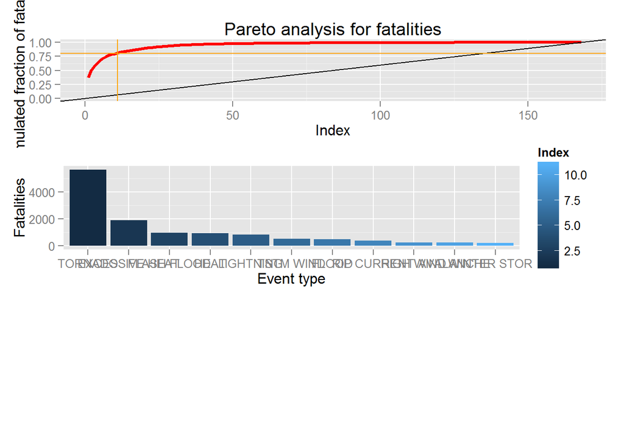

```
## [1] 2
```

```r
multiplot(par1,par2,ncol=2)
```

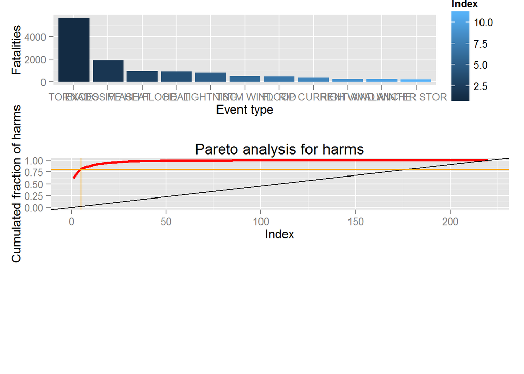

```
## [1] 2
```

```r
multiplot(par2,par3,ncol=2)
```

### Studying the economic impact of storms

Our working data are still quite big, we delete the observations for which the cost was zero.

```r
eco_data<-eco_data[which(eco_data$PROPDMG>0|eco_data$CROPDMG>0),]
```

We aggregate the data with the cost exponent for crops and property damages, so that overall costs can easily be computed. Once the overall cost are computed, we aggregate once more the overall costs versus `EVTYPE`.

```r
agg_eco<-aggregate(cbind(PROPDMG,CROPDMG)~EVTYPE+PROPDMGEXP+CROPDMGEXP,data=eco_data,FUN=sum)
agg_eco$overall<-0
for (i in 1:length(agg_eco[,1])){
        if(toupper(agg_eco$PROPDMGEXP[i])=="M"){
                agg_eco$PROPDMG[i]<-agg_eco$PROPDMG[i]*10^6
        }else if (toupper(agg_eco$PROPDMGEXP[i])=="K"){
                agg_eco$PROPDMG[i]<-agg_eco$PROPDMG[i]*10^3
        }else if (toupper(agg_eco$PROPDMGEXP[i])=="B"){
                agg_eco$PROPDMG[i]<-agg_eco$PROPDMG[i]*10^9
        }
        if(toupper(agg_eco$CROPDMGEXP[i])=="M"){
                agg_eco$CROPDMG[i]<-agg_eco$CROPDMG[i]*10^6
        }else if (toupper(agg_eco$CROPDMGEXP[i])=="K"){
                agg_eco$CROPDMG[i]<-agg_eco$CROPDMG[i]*10^3
        }else if (toupper(agg_eco$CROPDMGEXP[i])=="B"){
                agg_eco$CROPDMG[i]<-agg_eco$CROPDMG[i]*10^9
        }
        agg_eco$overall[i]<-agg_eco$CROPDMG[i]+agg_eco$PROPDMG[i]
}

agg_eco<-aggregate(overall~EVTYPE,data=agg_eco,na.rm=TRUE,FUN=sum)
agg_eco<-agg_eco[order(-agg_eco$overall),]


agg_eco$Cumulated<-0
agg_eco$Index<-1
index_cost<-NULL
total_cost<-sum(agg_eco$overall,na.rm=TRUE)
agg_eco$Cumulated[1]<- agg_eco$overall[1]/total_cost
for (i in 2:length(agg_eco$overall)){
        agg_eco$Cumulated[i]<-(agg_eco$overall[i]/total_cost + agg_eco$Cumulated[i-1])
        agg_eco$Index[i]<-i
}

for (i in 2:length(agg_eco$Cumulated)){
        if (agg_eco$Cumulated[i]>0.8){
                index_eco<-(i)
                break
        }
}
```

The Pareto curve for the overall costs versus `EVTYPE` can be computed.

```r
par5<-ggplot(data=agg_eco,aes(Index,Cumulated))
par5<-par5+geom_line(ylab="Cumulated percentage of costs",col='red',size=1.1)
par5<-par5+labs(y="Fraction of overall costs",title="Pareto analysis for costs")
par5<-par5+xlim(c(0,NA))+ylim(c(0,1))
par5<-par5+geom_abline(intercept=0,slope=(1/length(agg_eco$Cumulated)))
par5<-par5+geom_abline(intercept=0.8,slope=0,col='orange',size=0.5)
par5<-par5+geom_vline(xintercept=as.numeric(index_eco),col='orange',size=0.5)
```

We can also extract the most critical events in a subset,

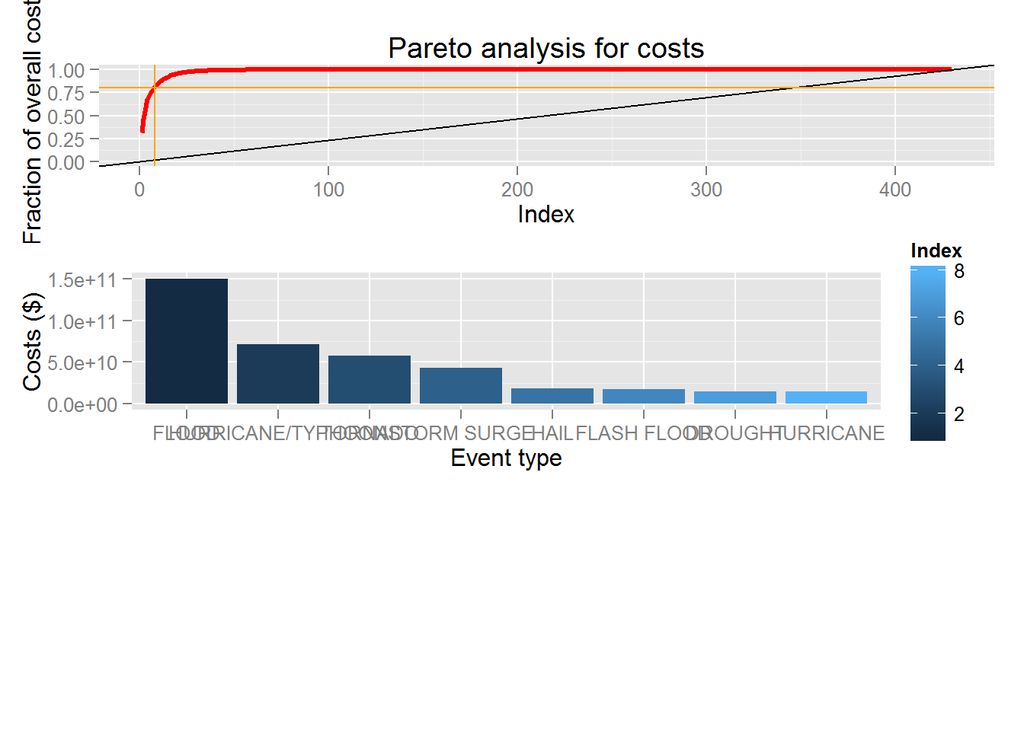

```
## [1] 2
```

```r
agg_crit3<-agg_eco[1:index_eco,]
par6<-qplot(weight=overall,reorder(EVTYPE,-overall),data=agg_crit3,geom="bar",ylab="Costs ($)",xlab="Event type",fill=Index,title="Main sources of cost among storms")

multiplot(par5,par6,ncol=2)
```

## Results

The Pareto analysis which was performed for the three different cases allowed us to answer a basic question : on what events types rely 80% of the effect (fatalities, harms or cost).

- For fatalities, the main events are :

```r
agg_crit$EVTYPE
```

```
##  [1] TORNADO        EXCESSIVE HEAT FLASH FLOOD    HEAT
##  [5] LIGHTNING      TSTM WIND      FLOOD          RIP CURRENT
##  [9] HIGH WIND      AVALANCHE      WINTER STORM
## 985 Levels:    HIGH SURF ADVISORY  COASTAL FLOOD ... WND
```

- For fatalities and injuries, the main events are :

```r
agg_crit2$EVTYPE
```

```
## [1] TORNADO        EXCESSIVE HEAT TSTM WIND      FLOOD
## [5] LIGHTNING
## 985 Levels:    HIGH SURF ADVISORY  COASTAL FLOOD ... WND
```

We see that the effects are even more concentrated on fewer causes.

- For costs, the main events are :

```r
agg_crit3$EVTYPE
```

```
## [1] FLOOD             HURRICANE/TYPHOON TORNADO           STORM SURGE
## [5] HAIL              FLASH FLOOD       DROUGHT           HURRICANE
## 985 Levels:    HIGH SURF ADVISORY  COASTAL FLOOD ... WND
```